# Years of life lost due to substance misuse

Sandy Knight

2024-12-07

## Required packages

```r
library(dplyr)
library(ggplot2)
library(janitor)
library(openxlsx)
library(stringr)
library(arrow)
library(tidyr)
library(glue)
library(scales)
```

## Source files

Some `{ggplot}` styling files, not necessary for analysis but plotting functions will fail without them

```r
source("R/themes.R")
source("R/dhsc_colour_palette.R")
```

## Getting the data

Each of these functions take no arguments and return a raw dataset when called.

### Drug poisoning data

The ONS publishes drug poisonings and classifies them as “related to drug misuse” given certain criteria i.e. specific ICD-10 codes on the death record.

The linkage of NDTMS and ONS data reveals that some deaths that had insufficient information for the ONS to apply this classification are probably related to drug misuse since they occured either in treatment or within a year of discharge. This analysis uses data from both sources to adjust the total number of deaths to include these additional deaths.

The functions in this section load each of the raw datasets when called.

### NDTMS-ONS linked dataset deaths

Drug poisoning deaths from the NDTMS-ONS data linkage. This function loads the required data from an Excel workbook received by email from EAT with the name `table1_all deaths_Cocaine version 1.xlsx`. Since loading data this large from Excel takes a long time it is saved as a parquet file to speed up later analysis. If this is already done the function does nothing. Note that this is not publicly available data.

```r
get_drug_poisoning_deaths <- function(){
if (!file.exists("data/raw/ndtms_mortality_data.parquet")) {
  #  This file is NDTMS-ONS data linkage; received by email from Stefan and
  #  named: "table1_all deaths_Cocaine version 1.xlsx"

  df <- # Load deaths data from Excel
    openxlsx::read.xlsx("data/raw/table1_all deaths_Cocaine version 1.xlsx",
                        sheet = "table1_all deaths")
  # Write data to easier format
  write_parquet(df, "data/raw/ndtms_mortality_data.parquet")

}
  # Return raw data
  read_parquet("data/raw/ndtms_mortality_data.parquet")

}
```

### ONS deaths related to drug poisoning

The ONS drug poisoning data is publicly available at the URI in this function. This function downloads, reshapes, and returns the relevant ONS data.

```r
get_ons_drug_poisoning_data  <-
function(){
url <- "https://www.ons.gov.uk/file?uri=/peoplepopulationandcommunity/birthsdeathsandmarriages/deaths/datasets/deathsrelatedtodrugpoisoningenglandandwalesreferencetable/current/2023registrations.xlsx"

ons_registrations <-
  openxlsx::read.xlsx(
    url,
    sheet = "Table 1",
    startRow = 4,
    sep.names = "_",
    fillMergedCells = TRUE,
    skipEmptyCols = TRUE,
    check.names = TRUE
  ) |>
  select(1,2,5,9)

colnames(ons_registrations) <- c("sex", "year", "all_drug_poisoning", "drug_misuse")

ons_registrations <-
ons_registrations |>
  slice(3:100) |>
  mutate(sex = zoo::na.locf(sex)) |>
  filter(sex == "Persons") |>
  as_tibble() |>
  filter(!is.na(year))

return(ons_registrations)
}
```

### Non-poisoning deaths of people with contact with the treatment system

The NDTMS-ONS data linkage also has records for people who died in treatment or after treatment from causes other than drug poisoning. This analysis adds those deaths to either drug- or -alcohol related deaths depending on the cause and, in the case of those people in treatment for drug use, time since discharge.

The treatment mortality data was received by email from EAT,(*received: 2024-07-08 from CA*) and named `post election data for Jon- sent.xlsx`. This data is not publicly available.

```r
get_non_poisoning_deaths <- function(){
np_deaths <-
  openxlsx::read.xlsx("data/raw/post election data for Jon- sent.xlsx", sheet = "NDTMS_ONS") |>
  janitor::clean_names()

np_deaths <-
np_deaths |>
  filter(geography == "LA")

return(np_deaths )

}
```

### ONS alcohol-specific deaths

The ONS alcohol-specific death data is publicly available at the URI in this function. This function downloads, reshapes, and returns the relevant ONS data.

```r
get_ons_alcohol_specific_death_data <-
  function(){

url <-
  "https://www.ons.gov.uk/file?uri=/peoplepopulationandcommunity/healthandsocialcare/causesofdeath/datasets/alcoholspecificdeathsbysexagegroupandindividualcauseofdeath/current/deathsbyindividualcause.xlsx"

alc_specific_deaths <-
read.xlsx(
  xlsxFile = url, rows = c(5:50), cols = c(1:24),colNames = TRUE, sheet = "Table 2") %>%
  rename_with(.fn = janitor::make_clean_names, .cols = 1:4)  |>
  rename("period" = year_note_3) %>%
  filter(sex != "Persons") |>
  tidyr::pivot_longer(cols = `<1`:`90+`, names_to = "age_group", values_to = "count") |>
  group_by(sex, age_group) |>
  summarise(count = sum(count), .groups = "drop")

return(alc_specific_deaths)
}
```

### Life expectancy

This function downloads, re-labels, and reshapes the ONS life tables for use in the YLL analysis.

```r
get_life_tables <- function() {
    url <- "https://www.ons.gov.uk/file?uri=/peoplepopulationandcommunity/birthsdeathsandmarriages/lifeexpectancies/datasets/nationallifetablesunitedkingdomreferencetables/current/nltuk198020203.xlsx"

    life_tables <-
        read.xlsx(
        xlsxFile = url,
        sheet = "2020-2022",
        startRow = 6
      ) |>
        rename_with(.cols = 1:6, ~paste0(.x, "_male")) |>
        rename_with(.cols = 7:12, ~paste0(.x, "_female")) |>
        select(ex_male, age_female, ex_female) |>
        pivot_longer(cols = contains("ex"), values_to = "ex", names_to = "sex") |>
        mutate(sex = str_remove(sex, "ex_")) |>
        rename("age" = age_female)

    return(life_tables)
}
```

## Data processing and preparation

### Drug deaths

The following two functions were written to allow other analyses of drug deaths and have more flexibilty (and therefore are unfortunately long and complicated) than is necessary for the YLL analysis. They should both take the output of the corresponding `get_*_data()` functions as the `data` argument. For this analysis we’ll choose to group the data by age and sex, and use date of occurrence rater than registration.

```r
#' Process drug poisoning data
#'
#' Reads, cleans, and processes drug poisoning data from a file. Filters and groups the data
#' based on user-defined parameters, such as years, date type, and grouping.
#'
#' @param file_path Path to the parquet file containing drug poisoning data.
#' @param date_of Either "occurrence" (year of death) or "registration" (year of registration).
#' @param years Vector of years to include in the analysis.
#' @param by Grouping variable: "area", "age", or NULL (national-level data).
#' @param by_sex Whether to group by sex
#' @return A tibble with grouped and summarized poisoning data.
process_poisoning_data <- function(data, date_of = "occurrence", years = c(2022, 2023), by = NULL, by_sex = FALSE) {
  if (is.null(by)) {
    message(paste("Drug poisoning: national level data, all ages", years, sep = ", "))
  }
  # Decide which date variable to use
  date_of_var <- switch(
    date_of,
    "occurrence" = "dod_year",
    "registration" = "reg_year",
    stop("Only 'occurrence' or 'registration' are valid options!")
  )

  # Handle grouping variable(s)
  if (!is.null(by)) {
    by_var <- switch(
      by,
      "area" = c("dat", "dat_nm"),
      "age" = "ageinyrs",
      stop("Invalid 'by' value. Use 'area', 'age', or leave as NULL.")
    )
  } else {
    by_var <- NULL
  }

 if (isTRUE(by_sex)){
   by_vars <- c(by_var, "sex")
 } else {
   by_vars <- by_var
 }

  # Read and process data
  result <-
  data %>%
    janitor::clean_names() %>%
    mutate(
      ndtms_match = if_else(
        treatment_status == "no match with NDTMS",
        "No record of contact with treatment system",
        "Record of contact with treatment system"
      ),
      ons_misuse = if_else(
        drug_misuse_combined == 1,
        "Recorded as drug misuse by ONS",
        "Not recorded as drug misuse by ONS"
      )
    ) %>%
    filter(
      # 'Total Deaths' only, not by substance. NB the substance groups are not mutually exclusive
      drug_group == "Total Deaths",
      # Year of occurrence OR registration as selected in the parameters
      .data[[date_of_var]] %in% years
    ) %>%
    filter(
      # Retain rows that were recoreded as drug misuse OR not recorded as drug misuse but have a record of contact with the treatment system
      drug_misuse_combined == 1 | (drug_misuse_combined == 0 & treatment_status != "no match with NDTMS")
    ) %>%
    mutate(
      additional_poisoning_deaths = if_else(
        # Where drug_misuse_combined equals 1
        drug_misuse_combined == 1,
        "Initial poisoning deaths",
        "Additional poisoning deaths"
      )
    ) %>%
    group_by(
      !!!syms(by_vars),
      !!!syms(date_of_var),
      additional_poisoning_deaths
    ) %>%
    summarise(
      count = n(),
      .groups = "drop"
    )

    if (isTRUE(by_sex)) {
    result <-
      result |>
      mutate(sex = case_match(sex,"M" ~ "male", "F" ~ "female"))
    }

  return(result)

}
```

```r
#' Process deaths in treatment data
#'
#' Reads and processes data about deaths in treatment. Filters, groups, and summarizes the data
#' based on various parameters.
#'
#' @param data A data frame produced by `get_non_poisoning_deaths`
#' @param years Vector of years to include in the analysis.
#' @param by Grouping variable: "area", "age", or NULL.
#' @param by_treatment_status Whether to group by treatment status.
#' @param by_death_cause Whether to group by cause of death.
#' @param by_sex Whether to group by sex
#' @param exclude_poisoning Whether to exclude drug poisoning deaths.
#' @param exclude_alcohol_specific_deaths Whether to exclude alcohol-specific deaths.
#' @return A tibble with grouped and summarized treatment data.
process_deaths_in_treatment <- function(data,
                                        years = c(2022, 2023),
                                        by = NULL,
                                        by_treatment_status = FALSE,
                                        by_death_cause = FALSE,
                                        by_sex = FALSE,
                                        exclude_poisoning = TRUE,
                                        exclude_alcohol_specific_deaths = TRUE
) {
  # Start with grouping variable
  grouping_vars <- "period"

  # Handle additional grouping by 'by' parameter
  if (!is.null(by)) {
    by_vars <- switch(by,
                      "area" = c("area_code", "area_name"),
                      "age" = "age",
                      stop("Invalid 'by' value. Choose 'area' or 'age', or leave as NULL.")
    )
    grouping_vars <- c(grouping_vars, by_vars)
  }

  # Add grouping for treatment status or death cause if requested
  if (isTRUE(by_treatment_status)) {
    grouping_vars <- c(grouping_vars, "treatment_status")
  }

  if (isTRUE(by_death_cause)) {
    grouping_vars <- c(grouping_vars, "death_cause")
  }

 if (isTRUE(by_sex)) {
    grouping_vars <- c(grouping_vars, "sex")
  }


  # Read and process data
  data <- data %>%
    mutate(    # Deal with Excel date madness
      period = as.Date(period, origin = "1899-12-30"),
      period = lubridate::year(period)
    )

  # Apply filters
  data <- data %>%
    filter(period %in% years)

  if (isTRUE(exclude_poisoning)) {
    data <- data %>%
      filter(death_cause != "Drug poisoning")
  }

  if (isTRUE(exclude_alcohol_specific_deaths)) {
    data <- data %>%
      filter(death_cause != "Alcohol-specific death")
  }

  # Group and summarize
  result <- data %>%
    group_by(across(all_of(grouping_vars))) %>%
    summarise(count = sum(count), .groups = "drop")

  # If grouped by sex column, standardise sex coding

  if (isTRUE(by_sex)) {
    result <-
    result |>
      mutate(sex = tolower(sex))
  }


  return(result)
}
```

### Alcohol deaths

This function extracts:  
1. alcohol-specific deaths in or after treatment and; 2. deaths of people in treatment for alcohol use only from the output of `get_non_poisoning_deaths()`

```r
get_alcohol_specific_deaths_from_tx <- function(data){
data |>
  filter(drug_group == "alcohol only"|death_cause == "Alcohol-specific death") |>
  filter(treatment_status != "Died one or more years following discharge")

}
```

### Age group parsing

These functions parse the age groups in the datasets that don’t have single-year-of-age fields to allow merging.

```r
# Simplified parse_age_groups function
parse_age_groups <- function(age_groups) {
  # Patterns for age group formats
  pattern_range <- "^([0-9]+)-([0-9]+)$"
  pattern_under <- "^<([0-9]+)$"
  pattern_over  <- "^([0-9]+)\\+$"

  # Initialize vectors
  lower <- rep(NA_real_, length(age_groups))
  upper <- rep(NA_real_, length(age_groups))

  # Identify which pattern each age group matches
  is_range <- grepl(pattern_range, age_groups)
  is_under <- grepl(pattern_under, age_groups)
  is_over  <- grepl(pattern_over, age_groups)

  # For range: extract lower and upper numbers
  if (any(is_range)) {
    lower[is_range] <- as.numeric(sub(pattern_range, "\\1", age_groups[is_range]))
    upper[is_range] <- as.numeric(sub(pattern_range, "\\2", age_groups[is_range]))
  }

  # For under: "<X" means lower = -Inf, upper = X
  if (any(is_under)) {
    upper[is_under] <- as.numeric(sub(pattern_under, "\\1", age_groups[is_under]))
    lower[is_under] <- -Inf
  }

  # For over: "X+" means lower = X, upper = Inf
  if (any(is_over)) {
    lower[is_over] <- as.numeric(sub(pattern_over, "\\1", age_groups[is_over]))
    upper[is_over] <- Inf
  }

  # Create and return a data frame
  data.frame(
    age_group = age_groups,
    lower = lower,
    upper = upper,
    stringsAsFactors = FALSE
  )
}
```

```r
assign_age_group <- function(ages, age_df) {
  # We assume ages is already an integer vector
  age_groups <- character(length(ages))

  # Assign age groups based on intervals
  for (i in seq_len(nrow(age_df))) {
    in_interval <- ages >= age_df$lower[i] & ages <= age_df$upper[i]
    age_groups[in_interval] <- age_df$age_group[i]
  }

  return(age_groups)
}
```

## Data merging

```r
merge_drug_deaths <- function() {
  # Process and aggregate poisoning deaths by age and sex for the specified year
  poisoning_deaths_by_age <-
    process_poisoning_data(
      data = get_drug_poisoning_deaths(), # Fetch raw drug poisoning death data
      date_of = "occurrence",             # Use date of occurrence (not registration date)
      years = 2022,                       # Only include data for the year 2022
      by = "age",                         # Aggregate results by age
      by_sex = TRUE                       # Also stratify by sex
    ) |>
    rename("age" = ageinyrs) |>           # Rename age variable
    group_by(age, sex) |>                 # Group by age and sex
    summarise(count = sum(count), .groups = "drop") # Summarise total counts and ungroup

  # Process and aggregate non-poisoning deaths that occur during treatment, by age and sex, for the same year
  non_poisoning_deaths_by_age <-
    process_deaths_in_treatment(
      data = get_non_poisoning_deaths(),    # Fetch non-poisoning death data
      years = 2022,                         # Only include data for the year 2022
      by = "age",                           # Aggregate results by age
      exclude_poisoning = TRUE,             # Ensure we exclude poisoning deaths
      by_treatment_status = TRUE,           # Consider treatment status categories
      by_death_cause = FALSE,               # Do not break down by specific cause of death
      by_sex = TRUE,                        # Stratify by sex
      exclude_alcohol_specific_deaths = TRUE # Exclude alcohol-specific deaths
    ) |>
    filter(treatment_status != "Died one or more years following discharge") |> # Filter out deaths occurring more than a year post-discharge
    group_by(age, sex) |>                   # Group by age and sex
    summarise(count = sum(count), .groups = "drop") # Summarise total counts and ungroup

  # Combine poisoning and non-poisoning deaths together, then aggregate by age and sex
  deaths_by_age <-
    bind_rows(
      poisoning_deaths_by_age,    # Add the poisoning deaths
      non_poisoning_deaths_by_age # Add the non-poisoning deaths
    ) |>
    group_by(age, sex) |>         # Re-group combined data by age and sex
    summarise(count = sum(count), .groups = "drop") |> # Sum all counts for each age/sex group
    mutate(substance = "Drugs")   # Add a variable to indicate these deaths are drug-related

  # Return the final aggregated data frame
  return(deaths_by_age)
}
```

```r
merge_alcohol_deaths <- function() {
  # Get ONS alcohol-specific death data
  ons_alc_deaths <- get_ons_alcohol_specific_death_data()

  # Get alcohol only deaths that occurred while in treatment, excluding alcohol-specific deaths
  alc_deaths_tx <-
    get_alcohol_specific_deaths_from_tx(get_non_poisoning_deaths()) |>
    # Focus on the specified time range and exclude rows categorised as "Alcohol-specific death"
    filter(period_range == "April 2021 to March 2022", death_cause != "Alcohol-specific death") |>
    # Group results by sex and age before summarising the count
    group_by(sex, age) |>
    summarise(count = sum(count, na.rm = TRUE), .groups = "drop")

  # Create a data frame that maps raw age values to defined age groups
  age_df <- parse_age_groups(pull(ons_alc_deaths, age_group))

  # Assign each death record from the treatment data to its corresponding age group
  # and re-summarise by sex and this new age group variable
  alc_deaths_tx <-
    alc_deaths_tx |>
    mutate(age_group = assign_age_group(pull(alc_deaths_tx, age), age_df = age_df)) |>
    group_by(sex, age_group) |>
    summarise(count = sum(count), .groups = "drop")

  # Combine the ONS alcohol-specific death data with the in-treatment alcohol-related death data
  # and then summarise counts by sex and age group
  alcohol_deaths <-
    bind_rows(alc_deaths_tx, ons_alc_deaths) |>
    group_by(sex, age_group) |>
    summarise(count = sum(count), .groups = "drop")

  # Convert 'sex' values to lower case, remove trailing 's', and label the substance as 'Alcohol'
  alcohol_deaths <-
    alcohol_deaths |>
    mutate(sex = tolower(sex)) |>
    mutate(sex = str_remove(sex, "s")) |>
    mutate(substance = "Alcohol")

  # Return the final aggregated dataset
  return(alcohol_deaths)
}
```

## Counts of aggregate deaths

These functions aggregate and plot the total count of deaths. The only categories are the substance, poisoning or non-poisoning, and whether they were counted in the initial ONS data or added from analysis of the linked dataset:

- Initial poisoning deaths
- Additional poisoning deaths
- Non-poisoning deaths: Died in treatment
- Non-poisoning deaths: Died within a year of discharge
- Non-poisoning deaths: Died one or more years following discharge *(not counted in the total)*

### Drugs

#### Combines poisoning and non-poisoning drugs deaths data

```r
#' Combine national data
#'
#' Merges poisoning data and treatment death data, ensuring consistent grouping by death category.
#'
#' @param poisoning_data Processed poisoning data.
#' @param treatment_deaths_data Processed treatment death data.
#' @return A tibble combining both datasets.
combine_national_data_drugs <- function(poisoning_data, treatment_deaths_data) {
  bind_rows(
    rename(poisoning_data, "death_category" = additional_poisoning_deaths) |>
      rename_with(.cols = 1, .fn = ~ str_remove(.x, "dod_|reg_")),
    rename(treatment_deaths_data, "death_category" = treatment_status, "year" = period)
  )
}
```

#### Gets (aggregates) national drugs deaths occurrences data for 2022

```r
get_national_data_drugs <- function() {
  combine_national_data_drugs(
    poisoning_data = process_poisoning_data(
      data = get_drug_poisoning_deaths(),
      date_of = "occurrence",
      years = 2022
    ),
    treatment_deaths_data = process_deaths_in_treatment(
      data = get_non_poisoning_deaths(),
      years = 2022,
      exclude_poisoning = TRUE,
      by_treatment_status = TRUE,
      by_death_cause = FALSE
    )
  )
}
```

#### Relabels national data for plot

```r
#' Relabel national data
#'
#' Adjusts labels for death categories, emphasizing poisoning and non-poisoning distinctions.
#'
#' @param national_data Combined national dataset.
#' @return A tibble with updated and ordered death category labels.
relabel_national_data <- function(national_data) {
  national_data |>
    mutate(death_category = case_when(
      str_detect(death_category, "poisoning") ~ death_category,
      TRUE ~ paste("Non-poisoning deaths:", death_category)
    )) |>
    mutate(
      death_category = factor(
        death_category,
        levels = rev(c(
          "Initial poisoning deaths",
          "Additional poisoning deaths",
          "Non-poisoning deaths: Died in treatment",
          "Non-poisoning deaths: Died within a year of discharge",
          "Non-poisoning deaths: Died one or more years following discharge"
        )),
        ordered = TRUE
      )
    )
}
```

#### Plots national drugs death data showing the additional deaths calculated using the data linkage

```r
# Function to create the plot
plot_national_data_drugs <- function(plot_data) {
  ttl <-
    plot_data |>
    filter(death_category != "Non-poisoning deaths: Died one or more years following discharge") |>
    pull(count) |> sum()


  ggplot(plot_data, aes(x = year, y = count)) +
    geom_col(
      aes(
        fill = death_category,
        alpha = death_category,
        linetype = death_category
      ),
      colour = "black",
      width = 0.45
    ) +
    geom_text(
      aes(
        label = scales::comma(count),
        group = death_category,
        alpha = death_category
      ),
      position = position_stack(0.5),
      size = 4
    ) +
    ggsci::scale_fill_lancet(alpha = 0.8) +
    theme_bw() +
    theme(
      text = element_text(size = 18),
      legend.position = "none",
      axis.ticks.x = element_blank(),
      panel.grid = element_blank()
    ) +
    scale_y_continuous(
      labels = scales::comma,
      breaks = c(2500, 5000, ttl, 10000)
    ) +
    scale_x_continuous(
      limits = c(2021, 2026),
      breaks = c(2022)
    ) +
    scale_alpha_manual(values = c(
      "Initial poisoning deaths" = 1,
      "Additional poisoning deaths" = 1,
      "Non-poisoning deaths: Died in treatment" = 1,
      "Non-poisoning deaths: Died within a year of discharge" = 1,
      "Non-poisoning deaths: Died one or more years following discharge" = 0.3
    )) +
    scale_linetype_manual(values = c(
      "Initial poisoning deaths" = 1,
      "Additional poisoning deaths" = 1,
      "Non-poisoning deaths: Died in treatment" = 1,
      "Non-poisoning deaths: Died within a year of discharge" = 1,
      "Non-poisoning deaths: Died one or more years following discharge" = 3
    )) +
    labs(
      fill = NULL,
      x = NULL,
      y = "Count of deaths",
      title = "Deaths associated with drug misuse"
    )
}
```

#### Adds annotations to national drugs deaths plot

```r
# Function to add annotations to the plot
add_plot_annotations <- function(plot, data) {
  # Filter data for the latest year
  ttl <-
    data |>
    filter(death_category != "Non-poisoning deaths: Died one or more years following discharge") |>
    pull(count) |> sum()

  latest_year <- max(data$year)
  annotation_data <- data %>%
    filter(year == latest_year) %>%
    arrange(rev(death_category)) %>%
    mutate(
      cumulative_count = cumsum(count),
      y_start = lag(cumulative_count, default = 0),
      y_end = cumulative_count,
      y_mid = (y_start + y_end) / 2
    )

  # Create a mapping of death categories to labels
  labels <- c(
    "Initial poisoning deaths" = "Drug poisoning deaths related to drug misuse\nas classified in ONS data",
    "Additional poisoning deaths" = "Drug poisoning deaths with a record of treatment\nbut not classified as related to drug misuse by ONS",
    "Non-poisoning deaths: Died in treatment" = "Deaths in treatment with a cause other than poisoning",
    "Non-poisoning deaths: Died within a year of discharge" = "Deaths within a year of leaving treatment with a cause\nother than poisoning",
    "Non-poisoning deaths: Died one or more years following discharge" = "Deaths a year or more after leaving treatment with a cause\nother than poisoning"
  )
  labels <- rev(labels)
  # Add annotations
  for (i in seq_len(nrow(annotation_data))) {
    row <- annotation_data[i, ]
    color <- ifelse(
      row$death_category == "Non-poisoning deaths: Died one or more years following discharge",
      "darkgrey",
      "black"
    )
    plot <- plot +
      geom_segment(
        x = latest_year + 0.3,
        xend = latest_year + 0.3,
        y = row$y_start,
        yend = row$y_end,
        arrow = arrow(
          ends = "both",
          angle = 90,
          length = unit(0.1, "cm")
        ),
        linewidth = 1,
        colour = color
      ) +
      annotate(
        "text",
        x = latest_year + 0.4,
        y = row$y_mid,
        label = labels[[ row$death_category]],
        hjust = 0,
        colour = color,
        size = 4
      )
  }
  plot <-
  plot +
    geom_segment(x = latest_year - 0.2, xend = latest_year - 1.1, y = ttl, yend = ttl ,linewidth = 1 , arrow = arrow(length = unit(.2, "cm")))


  return(plot)
}
```

#### Returns the aggregate deaths plot showing the total is composed of the relevant categories.

```r
create_national_drugs_deaths_plot <- function(){
 data <- get_national_data_drugs() |>
  relabel_national_data()

p <-
  plot_national_data_drugs(data)

p <-
  add_plot_annotations(plot = p, data = data)

return(p)
}
```

### Alcohol

```r
# This function pulls together national-level alcohol-related death data by:
# 1. Fetching total alcohol-specific deaths from ONS data.
# 2. Getting alcohol-specific deaths from treatment data (NDTMS), but excluding drug poisonings.
# 3. Replacing the alcohol-specific death counts in treatment data with the official ONS numbers
#    to avoid double counting.
combine_national_data_alcohol <- function() {
  # Step 1: Get the total alcohol-specific deaths from ONS, summed up.
  total_alc_spec_deaths_ons <-
    get_ons_alcohol_specific_death_data() |>
    summarise(count = sum(count)) %>%
    pull(count)

  # Step 2: From treatment data, filter to the desired period/range, remove drug poisonings,
  # and then sum up counts by cause.
  alcohol_deaths <-
    get_alcohol_specific_deaths_from_tx(data = get_non_poisoning_deaths()) |>
    filter(period_range == "April 2022 to March 2023", death_cause != "Drug poisoning") |>
    group_by(death_cause) |>
    summarise(count = sum(count), .groups = "drop") |>
    # Step 3: Replace the alcohol-specific deaths count with the ONS total to ensure accuracy.
    mutate(count = case_when(
      death_cause == "Alcohol-specific death" ~ total_alc_spec_deaths_ons,
      TRUE ~ count
    )) |>
    # Label categories by source
    mutate(death_category = if_else(
      death_cause == "Alcohol-specific death",
      "Alcohol-specific deaths (ONS)",
      "Additional deaths (NDTMS-ONS linkage)"
    ))

  # Return the combined alcohol death data.
  return(alcohol_deaths)
}
```

```r
# This function takes the combined alcohol death data and aggregates it by death category
aggregate_alcohol_deaths <- function(combined_national_alcohol_deaths) {
  aggregate_alcohol_deaths <-
    combined_national_alcohol_deaths |>
    group_by(death_category) |>
    summarise(count = sum(count), .groups = "drop")

  return(aggregate_alcohol_deaths)
}
```

```r
# This function plots the "additional alcohol deaths" from the combined data.
# It's a simple bar chart showing counts by cause, excluding the main alcohol-specific deaths (ONS).
plot_additional_alcohol_deaths <- function() {
  combine_national_data_alcohol() |>
    arrange(count) |>
    mutate(death_cause = forcats::as_factor(death_cause)) |>
    filter(death_category != "Alcohol-specific deaths (ONS)") |>
    ggplot(aes(y = death_cause, x = count)) +
    geom_col(
      width = 0.45,
      fill = dhsc_colour()[1],
      colour = "black"
    ) +
    my_theme +
    theme(
      legend.direction = "horizontal",
      legend.byrow = TRUE,
      plot.caption.position = "plot",
      plot.title.position = "plot"
    ) +
    # Add some descriptive labels and title
    labs(
      x = "Deaths (n)",
      y = NULL,
      title = "Additional alcohol deaths",
      subtitle = "by cause",
      caption = "Deaths in treatment or within a year of discharge April 2022 to March 2023
(with a cause other than 'alcohol-specific death', to avoid double counting with ONS)"
    )
}
```

### Drugs and alcohol

```r
# This function merges alcohol and drug-related mortality data into one dataset.
# It:
# 1. Fetches and relabels the drug data.
# 2. Gets the aggregated alcohol death data.
# 3. Categorises the deaths by source and substance.
# 4. Ensures consistent factor levels for plotting and analysis downstream.
get_merged_national_data <- function() {
  # Get the drugs data and do some relabelling and cleaning
  drugs_data <- get_national_data_drugs() |>
    relabel_national_data() |>
    mutate(substance = "Drugs")

  # Get the alcohol data and set the year to 2022
  alc_data <-
    combine_national_data_alcohol() |>
    aggregate_alcohol_deaths() |>
    mutate(substance = "Alcohol") |>
    mutate(year = 2022)

  # Remove deaths that occurred more than a year after discharge
  drugs_data <-
    drugs_data %>%
    filter(!str_detect(death_category, "one or more")) %>%
    select(-year)

  # Combine alcohol and drugs data together
  merged_data <-
    bind_rows(alc_data, drugs_data) %>%
    # Replace "poisoning deaths" phrase with "poisoning drug deaths" for clarity
    mutate(death_category = str_replace(death_category, "poisoning deaths", "poisoning drug deaths"))

  # Reassign 'substance' values with a consistent pattern
  merged_data <-
    merged_data %>%
    mutate(substance = c("alcohol", "alcohol", rep("drugs", 4)))

  # Change the alcohol death category names
  merged_data[c(1, 2), "death_category"] <-
    c(
      "Additional alcohol deaths",
      "Initial alcohol-specific deaths"
    )

  # Define factor levels for plotting.
  death_category_levels <-
    c(
      "Initial poisoning drug deaths",
      "Additional poisoning drug deaths",
      "Non-poisoning drug deaths: Died in treatment",
      "Non-poisoning drug deaths: Died within a year of discharge",
      "Initial alcohol-specific deaths",
      "Additional alcohol deaths"
    )

  # Re-factor the 'death_category' column so that categories appear in the desired order.
  merged_data <-
    merged_data %>%
    mutate(death_category = factor(death_category, levels = rev(death_category_levels)))

  # Drop the 'year' column since we don't need it in the final dataset.
  merged_data <-
    select(merged_data, -year)

  return(merged_data)
}
```

```r
# This function plots all deaths (both alcohol and drug-related) in a single stacked bar.
# It:
# 1. Merges data from alcohol and drugs into one dataset.
# 2. Summarizes them in a single column, with a dashed line showing the total sum.
# 3. Annotates counts on the bars and labels each category to the right of the bar.
plot_all_deaths_by_source <- function() {
  data <- get_merged_national_data()

  # Convert 'substance' to a more sentence-friendly format.
  data <-
    data |>
    mutate(substance = snakecase::to_sentence_case(substance))

  data |>
    ggplot(aes(x = 1, y = count)) +
    # A horizontal line showing total deaths
    geom_hline(yintercept = sum(data$count), linetype = 2) +
    # A single column, stacked by death_category, shaded by substance
    geom_col(aes(group = death_category, fill = substance), width = 0.45, alpha = 0.7, colour = "black") +
    # Display the counts as labels in the middle of each stack
    geom_text(
      aes(
        label = scales::comma(count),
        group = death_category
      ),
      position = position_stack(0.5),
      size = 4,
      colour = "black",
      fontface = "bold"
    ) +
    # Put the category labels to the right of the bar
    geom_text(aes(label = death_category, group = death_category, x = 1.4, y = count),
              position = position_stack(0.5), hjust = 0
    ) +
    # Apply custom theme and color scale
    my_theme +
    my_fill_scale +
    # Adjust x-axis limits and y-axis breaks for a nice look
    scale_x_continuous(limits = c(0.5, 4)) +
    scale_y_continuous(labels = scales::comma, breaks = c(0, 5000, 10000, sum(data$count))) +
    # Remove some gridlines and ticks for a cleaner look
    theme(
      axis.text.x = element_blank(),
      axis.ticks.x = element_blank(),
      panel.grid.major = element_blank(),
      panel.grid.minor = element_blank()
    ) +
    # Add labels and titles
    labs(
      x = NULL,
      y = "Deaths (n)",
      fill = NULL,
      title = "Estimated mortality associated with substance use",
      subtitle = "2022"
    )
}
```

## Calculating years of life lost (YLL)

### Initial estimate

The crude expected years of life lost is:

$$YLL = (D_{x})(e_{x}^s)$$

Where $D_x$ is the number of deaths in the age group and $e_{x}^s$ is the mean standard age of death from the external life expectancy (the ONS life tables) for the age. This is the method used by the Global Burden of Disease Study (GBD) [^1].

#### Calculates crude YLL

```r
calculate_crude_yll <- function() {
  # Step 1: Merge alcohol-related deaths into a single dataset
  alcohol_deaths <- merge_alcohol_deaths()

  # Step 2: Parse the age groups in the alcohol deaths data to get lower and upper bounds
  age_df <- parse_age_groups(pull(alcohol_deaths, age_group))

  # Step 3: Retrieve life tables, which contain life expectancy (ex) by sex and age
  life_tables <- get_life_tables()

  # Step 4: Calculate years of life lost (YLL) for alcohol-related deaths
  yll_alcohol <-
    life_tables |>
    # Assign each age in life tables to an age group based on parsed age group bounds
    mutate(age_group = assign_age_group(ages = age, age_df)) |>
    # Group by sex and age group and calculate the average life expectancy (ex)
    group_by(sex, age_group) |>
    summarise(ex = mean(ex), .groups = "drop") |>
    # Merge with alcohol deaths data to match life expectancy with death counts
    right_join(alcohol_deaths, by = c("sex", "age_group")) |>
    # Calculate YLL by multiplying life expectancy (ex) with the number of deaths (count)
    mutate(yll = ex * count)

  # Step 5: Summarise alcohol-related YLL and death counts by age group and substance
  yll_alcohol <-
    yll_alcohol |>
    group_by(age_group, substance) |>
    summarise(count = sum(count), yll = sum(yll), .groups = "drop")

  # Step 6: Merge drug-related deaths into a single dataset
  drug_deaths <- merge_drug_deaths()

  # Step 7: Calculate YLL for drug-related deaths
  yll_drugs <-
    left_join(
      drug_deaths,  # Join drug deaths data
      life_tables,  # With life tables to get life expectancy (ex) by sex and age
      by = c("sex", "age")
    ) |>
    # Calculate YLL by multiplying life expectancy (ex) with the number of deaths (count)
    mutate(yll = count * ex)

  # Step 8: Re-parse the age groups in the summarised alcohol YLL data
  age_df <- parse_age_groups(pull(yll_alcohol, age_group))

  # Step 9: Assign each age in drug YLL data to an age group based on parsed age group bounds
  yll_drugs <-
    mutate(yll_drugs, age_group = assign_age_group(age, age_df)) |>
    # Summarise drug-related YLL and death counts by age group and substance
    group_by(age_group, substance) |>
    summarise(count = sum(count), yll = sum(yll), .groups = "drop")

  # Step 10: Combine alcohol-related and drug-related YLL into a single dataset
  yll <- bind_rows(yll_alcohol, yll_drugs)

  # Step 11: Return the combined dataset
  return(yll)
}
```

### YLL with age-weighting and discounting

This function is from [here](https://static-content.springer.com/esm/art%3A10.1186%2F1471-2458-8-116/MediaObjects/12889_2007_1086_MOESM3_ESM.pdf)[^2]. It uses the same basic method but applies discounting and age-weighting.

The formula is:

$$Y_x = d_x \left[
\frac{KCe^{r(n^a_x)}}{(r+\beta)^2} \left( e^{z[-(r+\beta)(e^s_x + a_x) -
1]} - e^{-(r+\beta)a_x[-(r+\beta)a_x - 1]} \right) + \frac{1-K}{r} (1 -
e^{r(e^s_x)}) \right]$$
where:
𝑎 = age of death (years)
𝑟 = discount rate (usually 3%)
𝛽 = age weighting constant (usually 𝛽=0.04)
𝐾 = age-weighting modulation constant (usually 𝐾=1)
𝐶 = adjustment constant for age-weights (usually 𝐶=0.1658)
𝑒 = standard life expectancy at age of death (years)

The default values for these parameters were chosen and calibrated in the original Global Burden of Disease (GBD) study [^3]

#### Function to apply the formula:

```r
calculate_yll <-
  function(number.deaths,
           average.age.death,
           model.life.expectancy,
           discount.rate = 0.03,
           beta.constant = 0.04,
           modulation.constant = 0,
           adjustment.constant = 0.1658) {
    ## abbreviate inputs
    N <- number.deaths
    a <- average.age.death
    L <- model.life.expectancy
    r <- discount.rate
    b <- beta.constant
    K <- modulation.constant
    CC <- adjustment.constant
    ## do calculations
    if (discount.rate == 0) {
      N * (K * CC * ((exp(-b * a)) / b^2) * ((exp(-b * L)) * (-b * (L + a) - 1) - (-b * a - 1)) + ((1 - K) * L))
    } else {
      N * (K * ((CC * exp(r * a)) / (-(r + b)^2)) * ((exp(-(r + b) * (L + a)) * (-(r + b) * (L + a) - 1)) - (exp(-(r + b) * a) * (-(r + b) * a - 1))) + ((1 - K) / r) * ((1 - exp(-r * L))))
    }
  }
```

#### This function uses the `calculate_yll` function to estimate the total YLL for drug and alcohol use with discounting and age weighting.

```r
calculate_substance_use_yll <- function() {
  # Merge and summarise alcohol-related deaths by age group and sex
  alcohol_deaths <-
    merge_alcohol_deaths()

  # Create a data frame mapping age values to defined age groups, derived from alcohol_deaths
  age_df <-
    parse_age_groups(unique(pull(alcohol_deaths, age_group)))

  # Load life tables
  life_tables <-
    get_life_tables()
  # Incorporate age groups into life tables, then compute average age and life expectancy (ex) for each age group and sex
  life_tables <-
    life_tables |>
    mutate(age_group = assign_age_group(ages = pull(life_tables, age), age_df = age_df)) |>
    group_by(sex, age_group) |>
    summarise(mean_age = mean(age), ex = mean(ex), .groups = "drop")

  # Join alcohol deaths with the relevant life table data to calculate Years of Life Lost (YLL)
  alcohol_yll <-
    left_join(alcohol_deaths, life_tables) |>
    mutate(yll = calculate_yll(number.deaths = count, average.age.death = mean_age, model.life.expectancy = ex)) |>
    group_by(age_group, substance) |>
    summarise(count = sum(count), yll = sum(yll), .groups = "drop")

  # Merge and summarise drug-related deaths by age and sex
  drug_deaths <- merge_drug_deaths()

  # Get ONS life tables for drugs YLL calculation
  life_tables <- get_life_tables()

  # Join drug deaths data with life table data
  yll <-
    left_join(drug_deaths, life_tables)

  # Calculate YLL for drug-related deaths
  drugs_yll <-
    yll |>
    mutate(yll = calculate_yll(number.deaths = count, average.age.death = age, model.life.expectancy = ex))

  # Assign drug deaths to appropriate age groups using age_df generated above
  drugs_yll <-
    drugs_yll |>
    mutate(age_group = assign_age_group(ages = age, age_df)) |>
    group_by(age_group, substance) |>
    summarise(count = sum(count), yll = sum(yll), .groups = "drop")

  # Combine YLL estimates for both alcohol and drugs into one dataset
  substance_use_yll <- bind_rows(alcohol_yll, drugs_yll)

  # Return the final data frame containing combined YLL estimates for both alcohol and drug substances
  return(substance_use_yll)
}
```

#### Produces a plot of the crude YLL estimate

```r
plot_crude_yll_estimate <-
  function(){
source("R/dhsc_colour_palette.R")
source("R/themes.R")
crude_yll <-
  calculate_crude_yll()

p <-
crude_yll  |>
  ggplot(aes(x = age_group, y = yll)) +
  geom_col(aes(fill = substance), colour = "black") +
  scale_y_continuous(labels = scales::comma) +
  labs(
    title = "Estimated years of life lost (YLL), due to substance use",
    subtitle = glue::glue("Total YLL: {scales::comma(sum(crude_yll$yll))} (without discounting or age weighting)"),
    caption = "Data from ONS and NDTMS for deaths which occurred in 2022",
    fill = NULL,
    x = "Age group",
    y = "YLL"
       ) +
  my_theme + my_fill_scale +
  theme(
    axis.text.x = element_text(angle = 30, vjust = 0.5),
    legend.direction = "horizontal",
    plot.caption = element_text(face = "italic")
      )

return(p)
  }
```

#### Produces a similar plot for the discounted and age-weighted YLL estimate

```r
plot_substance_use_yll_estimate <-
  function(){
    source("R/dhsc_colour_palette.R")
    source("R/themes.R")

    yll <-
      calculate_substance_use_yll()

    yll |>
      ggplot(aes(x = age_group, y = yll)) +
      geom_col(aes(fill = substance), colour = "black") +
      scale_y_continuous(labels = scales::comma) +
      labs(
        title = "Estimated years of life lost (YLL), due to substance use",
        subtitle = glue::glue(
          "Total YLL: {scales::comma(sum(yll$yll))} (with discounting and age weighting)"
        ),
        caption = "Data from ONS and NDTMS for deaths which occurred in 2022",
        fill = NULL,
        x = "Age group",
        y = "YLL"
      ) +
      my_theme + my_fill_scale +
      theme(
        axis.text.x = element_text(angle = 30, vjust = 0.5),
        legend.direction = "horizontal",
        plot.caption = element_text(face = "italic")
      )

  }
```

## Comparing with leading causes of mortality

```r
get_all_cause_mortality <-
  function(){

    # Use cached file if it exists
    if (file.exists("data/processed/ons_leading_mortality_causes.csv")){

      # Download and process mortality data from ONS
      ons_leading_mortality_causes <-
        read.xlsx(
          xlsxFile = "https://www.ons.gov.uk/file?uri=/peoplepopulationandcommunity/birthsdeathsandmarriages/deaths/datasets/deathsregisteredinenglandandwalesseriesdrreferencetables/2022/dr2022corrected.xlsx",
          sheet = "10b",
          rows = c(6:55)) |>
        janitor::clean_names() |>
        as_tibble() |>
        mutate(percentage_of_all_deaths_percent = percentage_of_all_deaths_percent / 100) # convert to proportion

      return(ons_leading_mortality_causes)
    }
  }

merge_leading_cause_data <- function() {
  all_cause_mortality <- get_all_cause_mortality()
  alcohol_deaths <- merge_alcohol_deaths()
  drug_deaths <- merge_drug_deaths()

  # Identify common age groups of interest
  leading_mortality_age_groups <- unique(pull(all_cause_mortality, age_group))
  leading_mortality_age_groups <- leading_mortality_age_groups[4:7] # focus on mid-age ranges

  # Filter and select top 5 causes per age group
  all_cause_mortality <-
    all_cause_mortality |>
    filter(age_group %in% leading_mortality_age_groups) |>
    group_by(age_group) |>
    group_split() |>
    lapply(function(x) slice(arrange(x, -deaths), 1:5)) |>
    bind_rows()

  # Group drug deaths into similar age categories
  drug_deaths <-
    drug_deaths |>
    filter(age < 80, age > 18) |>
    mutate(age_group = cut(
      age,
      breaks = c(19, 34, 49, 64, 79),
      labels = c("20 to 34 years","35 to 49 years","50 to 64 years","65 to 79 years"),
      right = TRUE
    )) |>
    filter(age_group %in% leading_mortality_age_groups) |>
    group_by(substance, age_group) |>
    summarise(count = sum(count), .groups = "drop") |>
    mutate(leading_cause = "Deaths associated with drug use") |>
    select(-substance)

  # Map various age brackets to consistent age groups for alcohol data
  alcohol_deaths <-
    alcohol_deaths |>
    mutate(
      age_group =
        case_match(
          age_group,
          "20-24" ~ "20 to 34 years",
          "25-29" ~ "20 to 34 years",
          "30-34" ~ "20 to 34 years",
          "35-39" ~ "35 to 49 years",
          "40-44" ~ "35 to 49 years",
          "45-49" ~ "35 to 49 years",
          "50-54" ~ "50 to 64 years",
          "55-59" ~ "50 to 64 years",
          "60-64" ~ "50 to 64 years",
          "65-69" ~ "65 to 79 years",
          "70-74" ~ "65 to 79 years",
          "75-79" ~ "65 to 79 years"
        )
    ) |>
    filter(!is.na(age_group)) |>
    group_by(substance, age_group) |>
    summarise(count = sum(count), .groups = "drop") |>
    mutate(leading_cause = "Deaths associated with alcohol use") |>
    select(-substance)

  # Combine all cause mortality with drug and alcohol data
  all_cause_mortality <-
    all_cause_mortality |>
    select(age_group, leading_cause, deaths) |>
    rename("count" = deaths)

  leading_cause_mortality_comparison <-
    bind_rows(list(
      all_cause_mortality,
      alcohol_deaths,
      drug_deaths
    )) |>
    group_by(age_group) |>
    group_split()

  return(leading_cause_mortality_comparison)
}

prepare_leading_cause_data <- function(data, substance) {
  # Separate out main causes vs. drug/alcohol-associated ones
  causes <- pull(filter(data, !str_detect(leading_cause, "drug|alcohol")), leading_cause)

  # If combined, sum drug & alcohol counts together
  if (substance == "combined") {
    data <-
      data |>
      filter(leading_cause %in% c("Deaths associated with drug use","Deaths associated with alcohol use")) |>
      group_by(age_group) |>
      summarise(count = sum(count), .groups = "drop") |>
      mutate(leading_cause = "Deaths associated with drug and alcohol use") |>
      bind_rows(filter(data, !leading_cause %in% c("Deaths associated with drug use","Deaths associated with alcohol use")))
  } else {
    # Pick the substance of interest, or both simultaneously
    substance <-
      switch(substance,
             "drugs" = "Deaths associated with alcohol use",
             "alcohol" = "Deaths associated with drug use",
             "both" = c("Deaths associated with drug use", "Deaths associated with alcohol use")
      )

    data <-
      data |>
      filter(leading_cause %in% c(substance, causes))

    return(data)
  }
}

iterate_data_preparation <- function(substance) {
  leading_cause_mortality_comparison <- merge_leading_cause_data()
  # Apply preparation for each age group subset
  lapply(leading_cause_mortality_comparison, function(data) prepare_leading_cause_data(data = data, substance = substance))
}

leading_cause_mortality_comparison <- function(){
  # Prepare data for each scenario
  lapply(X = c("drugs", "alcohol", "both", "combined"), FUN = iterate_data_preparation) |>
    unlist(recursive = FALSE)
}

plot_leading_cause_comparison <-
  function(data) {
    # Bar plot comparing count of deaths by causes vs drugs and alcohol
    data |>
      arrange(count) |>
      mutate(leading_cause = forcats::as_factor(leading_cause)) |>
      ggplot(aes(x = count, y = leading_cause, fill = leading_cause)) +
      geom_col() +
      scale_fill_manual(values = c("Deaths associated with drug use" = "red", "Deaths associated with alcohol use" = "red", "Deaths associated with drug and alcohol use" = "red")) +
      my_theme +
      theme(legend.position = "none") +
      scale_x_continuous(labels = scales::comma) +
      labs(x = "Deaths (n)", y = NULL, subtitle = unique(data$age_group))
  }
```

## Plotting results

### Plot count of drug deaths

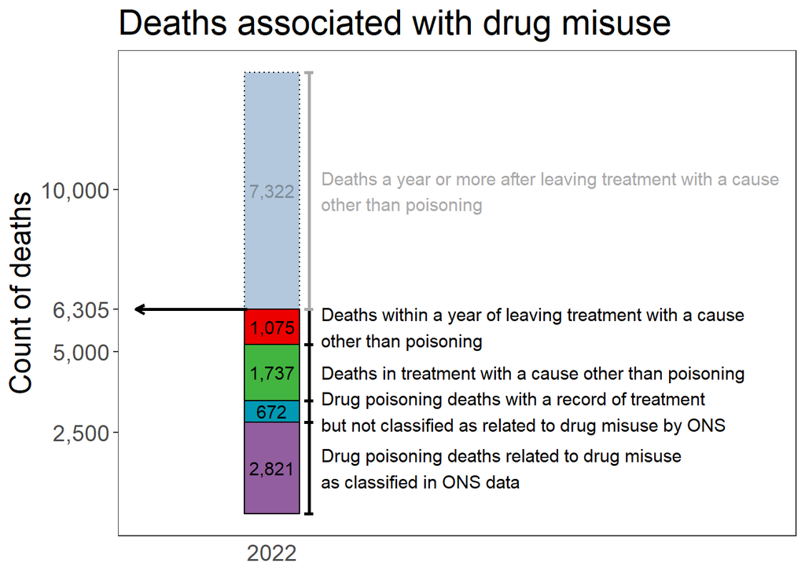

```r
create_national_drugs_deaths_plot()
```

### Plot additional alcohol deaths

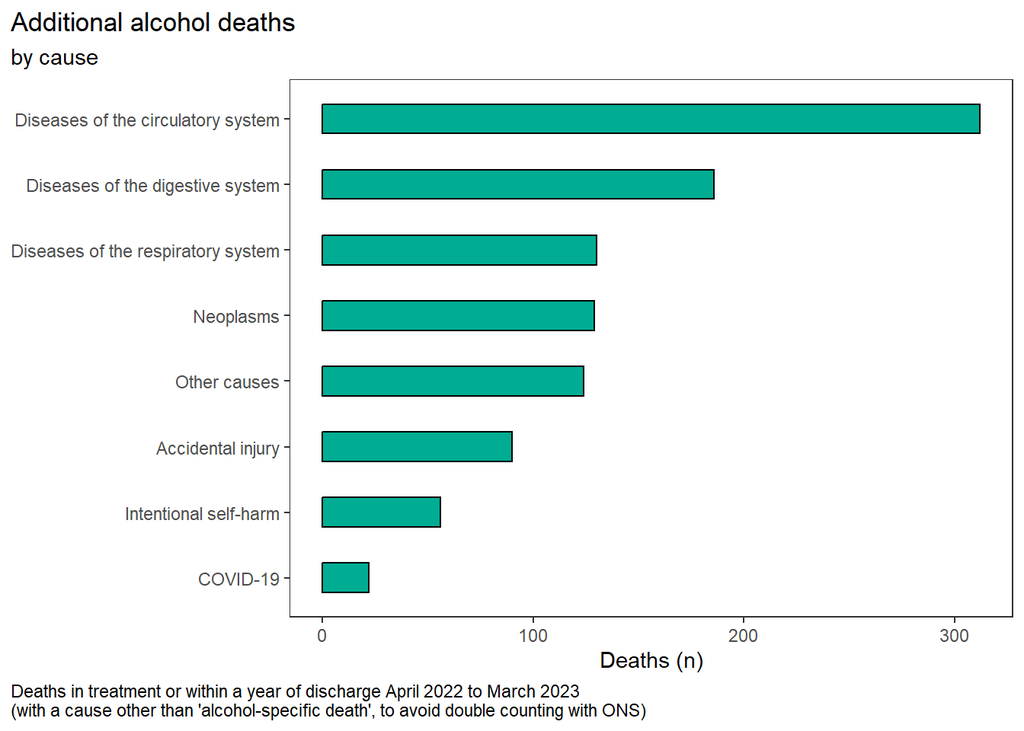

```r
plot_additional_alcohol_deaths()
```

### Plot all deaths by substance and source

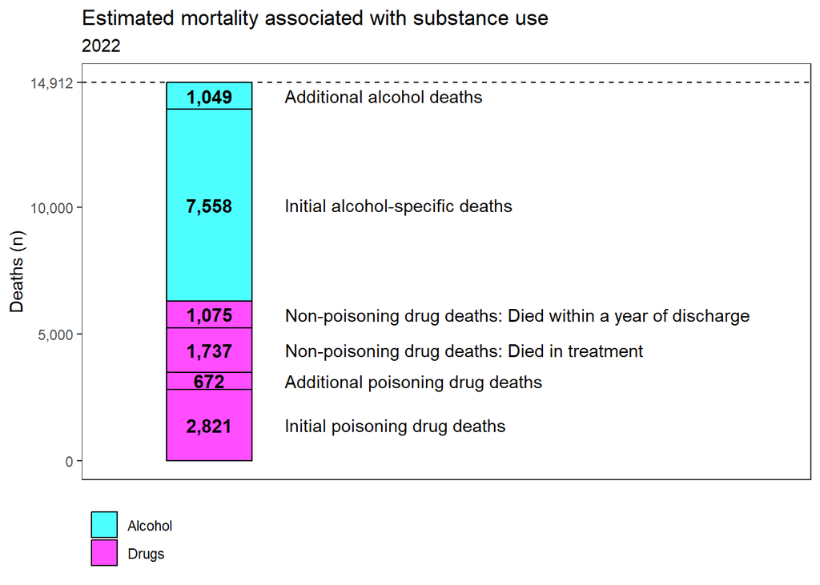

```r
plot_all_deaths_by_source()
```

### Plot YLL crude estimate

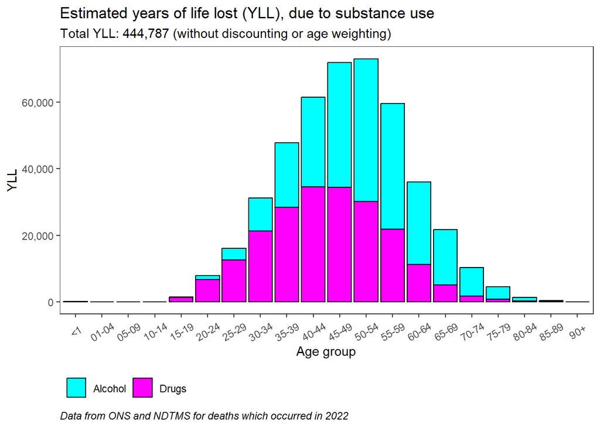

```r
plot_crude_yll_estimate()
```

### Plot discounted and weighted estimate

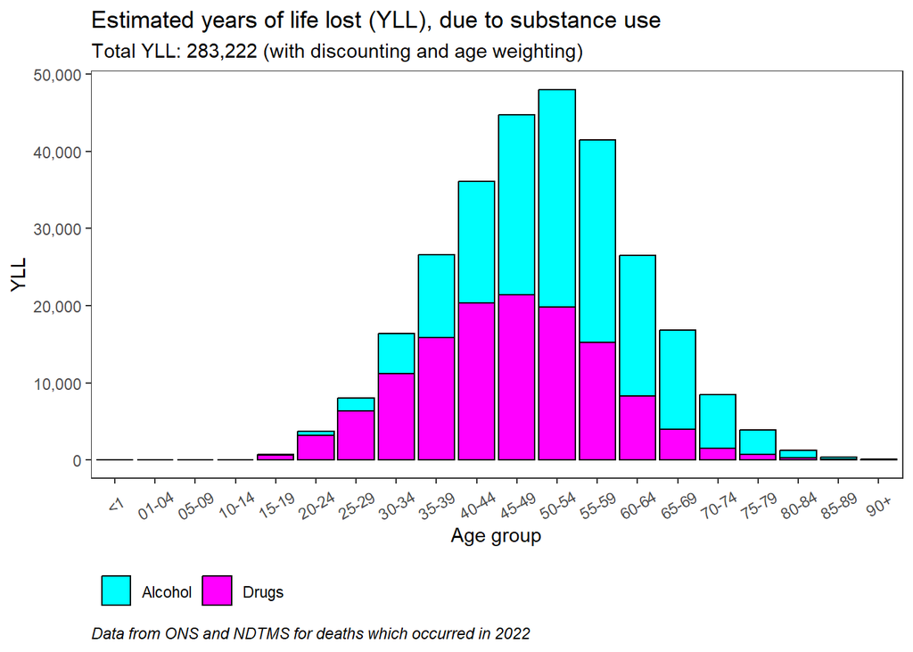

```r
plot_substance_use_yll_estimate()
```

### Plot comparisons with leading causes

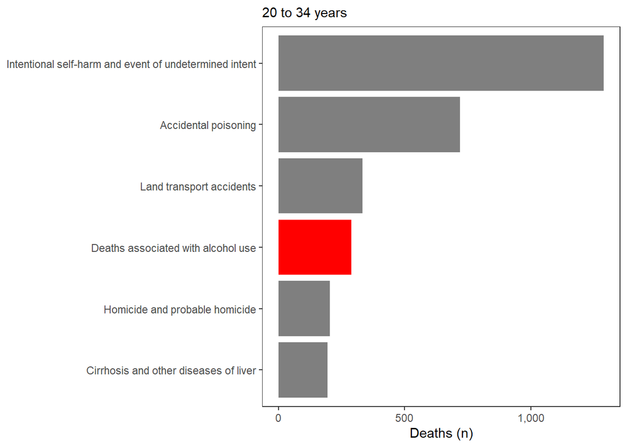

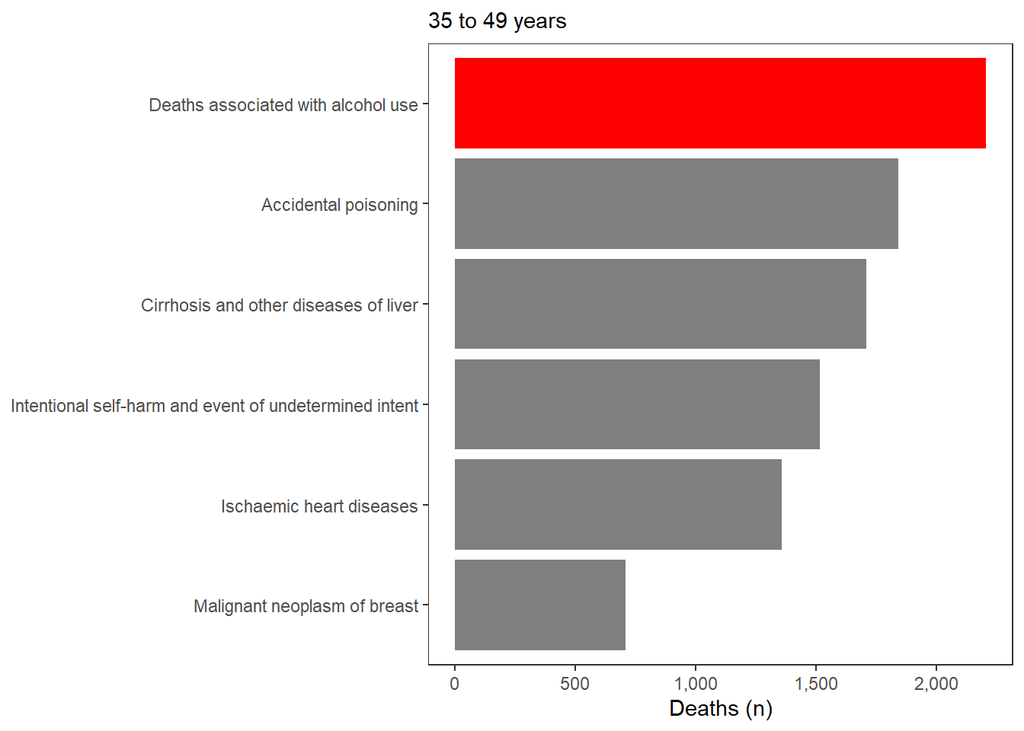

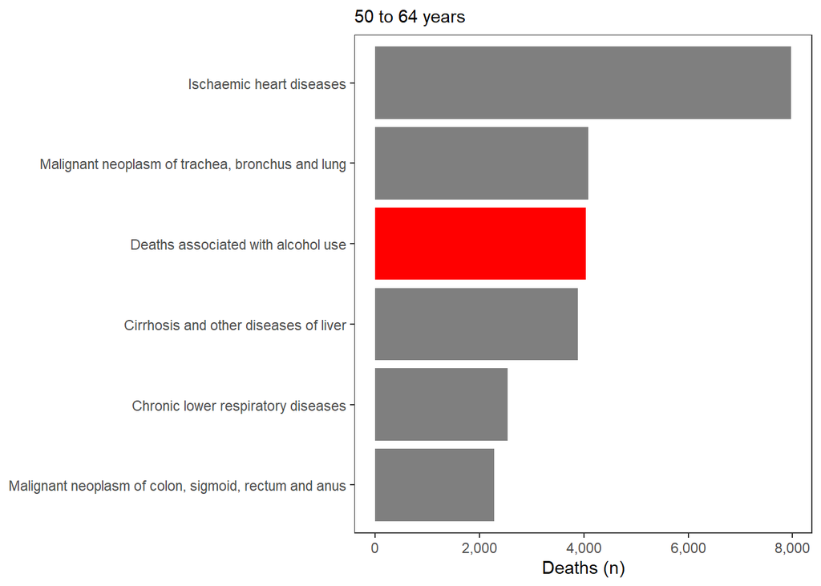

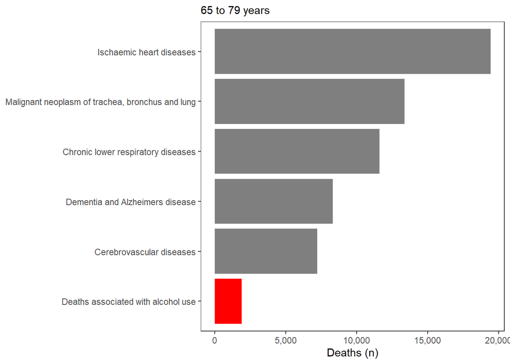

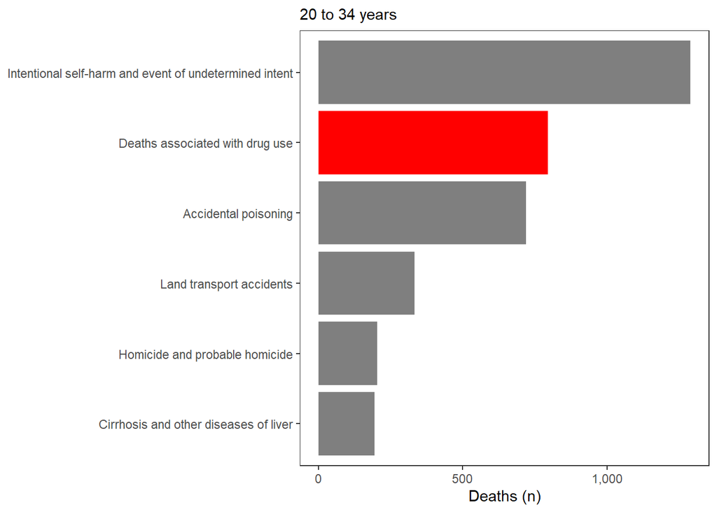

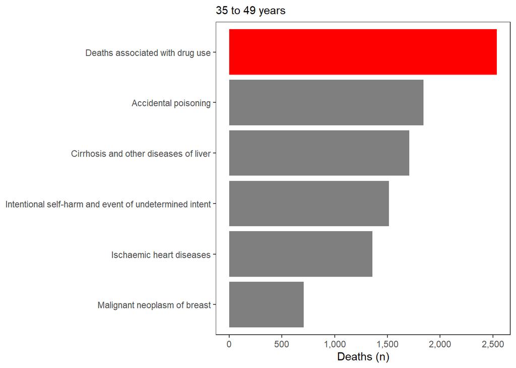

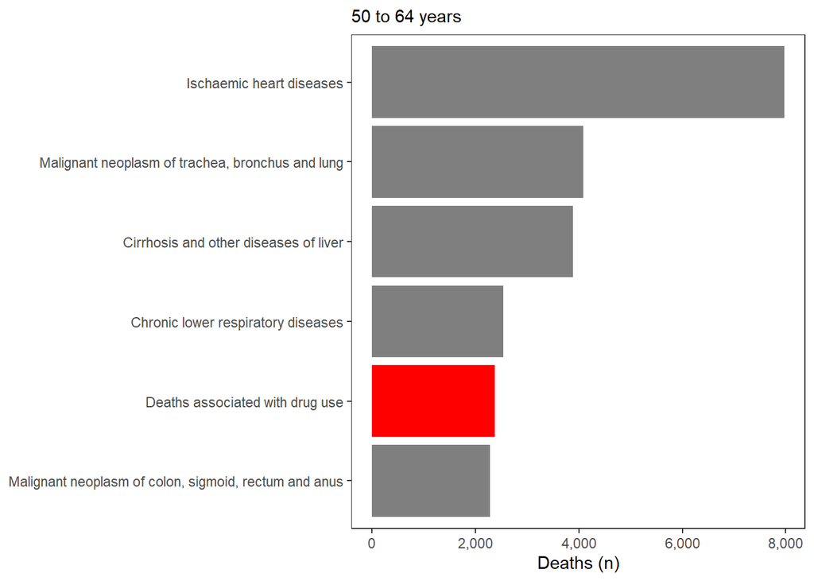

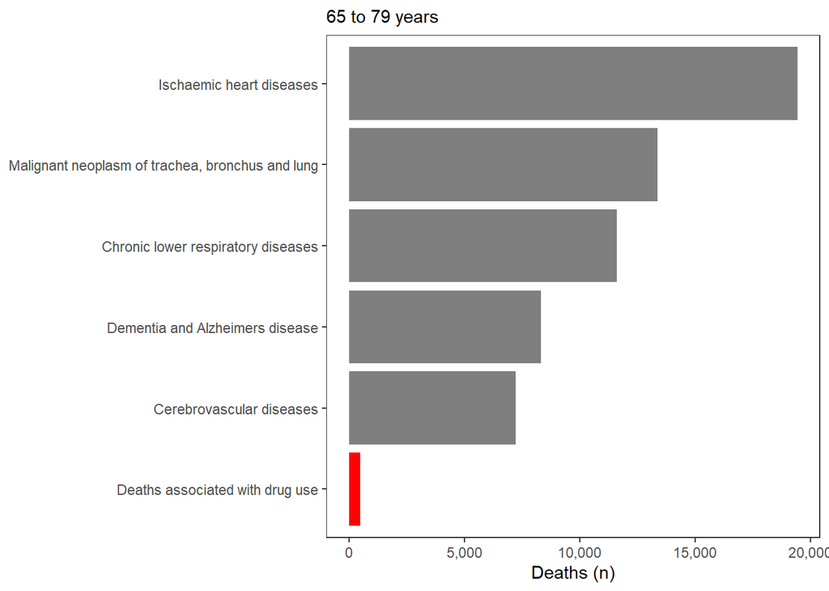

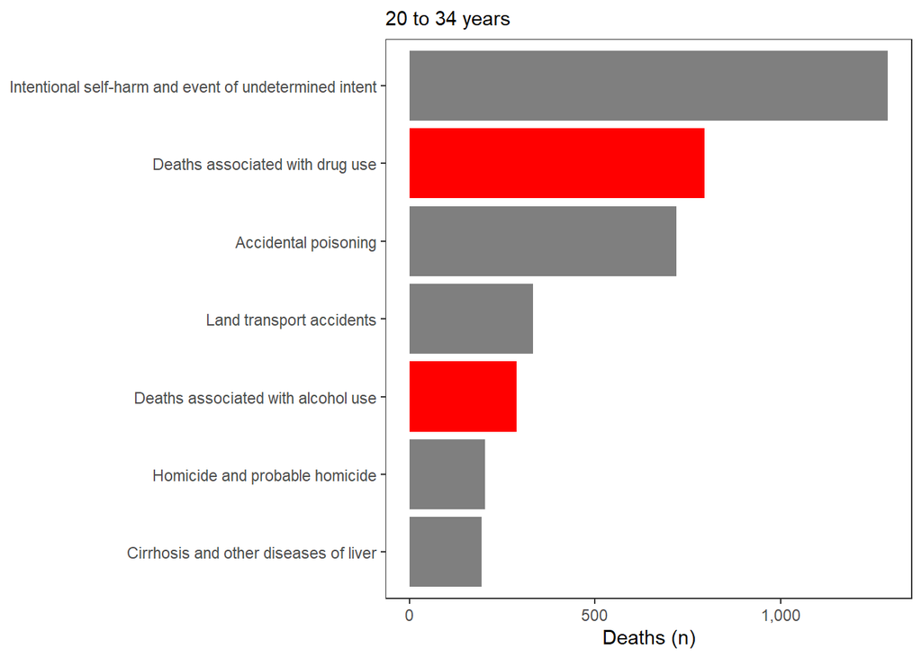

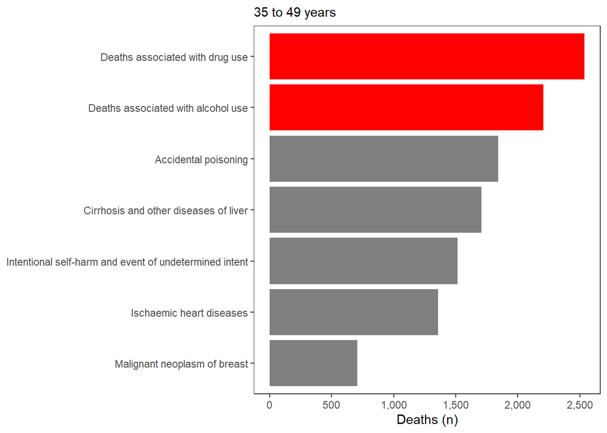

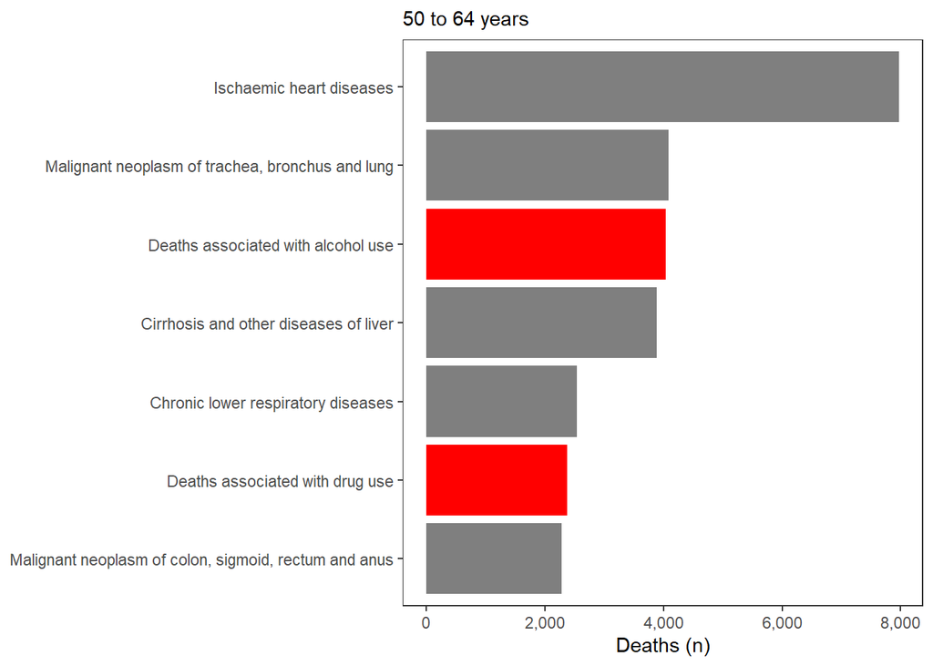

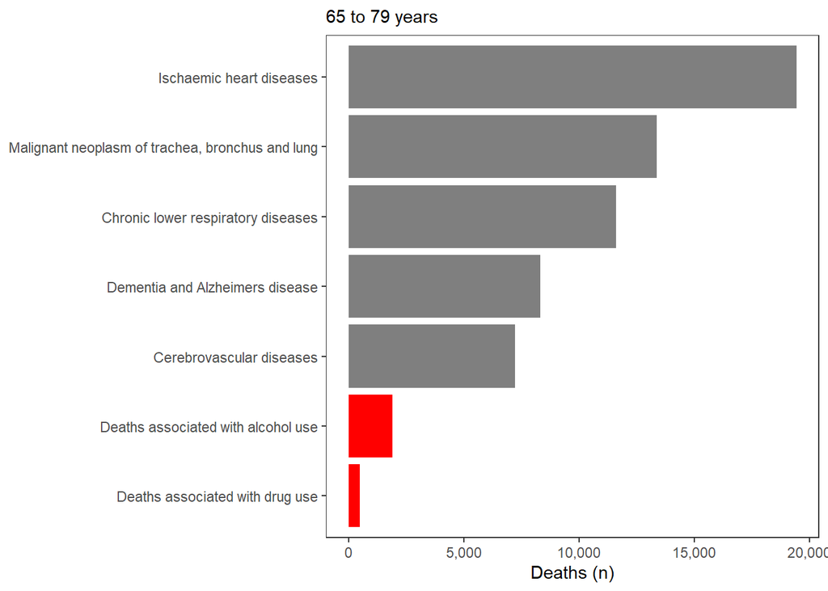

[4 more figures not shown]

```r
lc_plots <- lapply(leading_cause_mortality_comparison(), plot_leading_cause_comparison)

lc_plots
```

[^1]: Chudasama, Y.V., Khunti, K., Gillies, C.L., Dhalwani, N.N., Davies, M.J., Yates, T., & Zaccardi, F. (2022). Estimates of years of life lost depended on the method used: tutorial and comparative investigation. *Journal of Clinical Epidemiology*, 150, pp. 42–50. Available at: https://doi.org/10.1016/j.jclinepi.2022.06.012 [Accessed 6 Nov. 2024].
[^2]: Aragón, T.J., Lichtensztajn, D.Y., Katcher, B.S., Reiter, R. and Katz, M.H., 2007. Calculating Expected Years of Life Lost to Rank the Leading Causes of Premature Death in San Francisco. *San Francisco Department of Public Health*.
[^3]: Murray, C.J., Lopez, A.D. and Jamison, D.T., 1994. The global burden of disease in 1990: summary results, sensitivity analysis and future directions. *Bulletin of the world health organization*, 72(3), p.495.